# Case Study Dataset Review

This is a brief review of the possible datasets I could use with results from PCA and PLS.

# 1 Mourning Cloaks

```r
mocl <- read_rds(here::here("data", "mourning-cloaks", "mocl-seasonal.rds"))
```

## 1.1 Data Source

Butterfly survey data is combined with weather data for MA from NOAA.

## 1.3 Original analysis

N/A—this is not a published dataset

## 1.4 PCA

```r
pca <- opls(select(mocl, -MOCL, -MOCL_fall, -year), plotL = FALSE)
```

```
PCA
20 samples x 34 variables
standard scaling of predictors
1 excluded variables (near zero variance)
```

|  | R2X(cum) | pre | ort |
| --- | --- | --- | --- |
| Total | 0.597 | 3 | 0 |

**Loadings:**

```r
get_loadings(pca) %>%
  arrange(desc(abs(p1)))
```

| Variable | p1 | p2 | p3 |
| --- | --- | --- | --- |
| Sp_mean_avg_temp | -0.28337097 | 0.07085724 | -1.353069e-01 |
| Sp_mean_max_temp | -0.27431462 | 0.02110927 | -8.889982e-02 |
| Su_mean_max_temp | -0.27375428 | -0.02516411 | 2.574442e-01 |
| Sp_sum_hdd | 0.26536152 | -0.05251465 | 1.645969e-01 |
| Su_mean_avg_temp | -0.25440429 | 0.04762028 | 2.725403e-01 |
| Su_sum_cdd | -0.25278712 | 0.05155203 | 2.623583e-01 |
| Sp_mean_min_temp | -0.24568842 | 0.13242905 | -1.738025e-01 |
| Sp_sum_cdd | -0.22898393 | 0.10249428 | 1.736551e-02 |
| Su_sum_hdd | 0.21931452 | -0.02093385 | -2.594459e-01 |
| Su_mean_min_temp | -0.19140657 | 0.12465707 | 2.498698e-01 |

[output cut: 24 more lines]

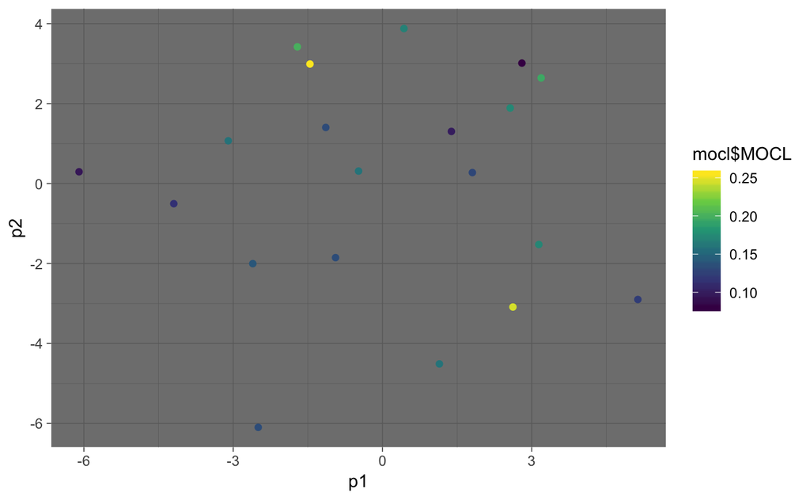

```r
get_scores(pca) %>%
  ggplot(aes(x = p1, y = p2, color = mocl$MOCL)) +
  geom_point() +
  scale_color_viridis_c() +
  theme_dark()
```

## 1.6 PLSR

PLS model is non-significant

```r
plsr <- try(opls(select(mocl, -MOCL, -MOCL_fall, -year), mocl$MOCL_fall))
```

```
The variance of the 1 following variables is less than 2.2e-16 in the full or partial (cross-validation) dataset: these variables will be removed:
Wi_sum_cddError : No model was built because the first predictive component was already not significant;
Select a number of predictive components of 1 if you want the algorithm to compute a model despite this.
```

If I force one predictive component, the $Q^2$ value is negative. I would conclude the model is not significant.

**OPLS plot:**

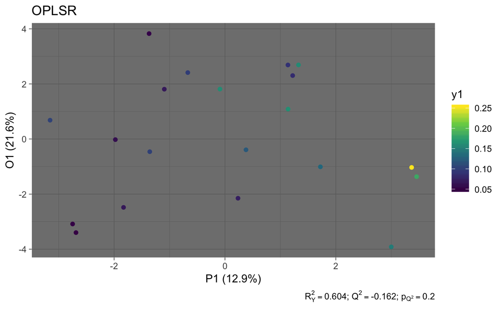

```r
plsr <- opls(select(mocl, -MOCL, -MOCL_fall, -year), mocl$MOCL_fall, predI = 1, orthoI = 1, plotL = FALSE, printL = FALSE)
plot_opls(plsr) + theme_dark()
```

**OPLS loadings:**

The loadings show Summer is more important for Fall mourning cloak abundance while PCA pulls out Spring as most variation in the data.

```r
get_loadings(plsr) %>%
  arrange(desc(abs(p1)))
```

| Variable | p1 |
| --- | --- |
| Su_mean_max_temp | -0.33694288 |
| Su_mean_avg_temp | -0.33603563 |
| Su_sum_cdd | -0.32974533 |
| Su_mean_pdsi | 0.30700456 |
| Su_sum_hdd | 0.30284540 |
| Su_mean_min_temp | -0.28572062 |
| Sp_sum_precip | 0.27249609 |
| Sp_mean_pdsi | 0.26237538 |
| Au_sum_precip | -0.22763307 |
| Au_sum_precip_prev | 0.19577557 |

[output cut: 24 more lines]

# 2 Tomatoes

```r
tomato <- read_rds(here::here("data", "literature", "Muir et al.", "tomatoes.rds"))
tomato.filtered <- tomato %>%
  filter(precip < 2000)
```

## 2.1 Data source

From a [paper](https://nph.onlinelibrary.wiley.com/doi/epdf/10.1111/nph.14285) in New Phytologist by Muir et al.

## 2.2 Data description

9 leaf traits measured on 16 species of *Solanum* with 3-5 individuals per species. For each species, they include a lattitude and longitude, which I used to pull temperature and precipitation data from WorldClim, like they describe in the paper.

## 2.3 Original Analysis

They measure leaf traits in several *Solanum* species, do PCA to re-capitulate the leaf economics spectrum (LES), and then use that PC in a phylogenetic regression (to see how LES varied within and among species), and in a regression with the mean precip and temp of species habitats (to see if LES varies by habitat type). Instead, we could ask “what leaf traits vary by temperature or precipitation?”

They show that the correlation between PC1 and precipitation is only significant if a species that grows in very wet habitats (*S. juglandifolium*) is included. With that species included, PC1 is a significant predictor of precipitation but not temperature. Without it, PC1 is a significant predictor of temperature, but not precipitation.

I played around with this species a bit, and either way the PLSR **is significant for both temp and precip**.

## 2.4 PCA

I’m going to use the data without *S. juglandifolium* for now and focus on precipitation.

```r
# tom.pca <- opls(tomato %>% dplyr::select(lma.leaflet:Rdark), plotL = FALSE)
tom.pca <- opls(tomato.filtered %>% dplyr::select(lma.leaflet:Rdark), plotL = FALSE)
```

```
PCA
65 samples x 9 variables
standard scaling of predictors
4 (1%) NAs
```

|  | R2X(cum) | pre | ort |
| --- | --- | --- | --- |
| Total | 0.558 | 2 | 0 |

**Loadings:**

```r
get_loadings(tom.pca) %>%
  arrange(desc(abs(p1)))
```

| Variable | p1 | p2 |
| --- | --- | --- |
| A | -0.52306426 | 0.17447881 |
| gm | -0.49354022 | 0.03704827 |
| Vcmax | -0.40798058 | -0.30744432 |
| lma.leaflet | 0.33674532 | 0.03322171 |
| gs | -0.26581055 | 0.54629311 |
| ldmc | 0.23828459 | 0.33710175 |
| thick.vile | 0.19932311 | -0.33392317 |
| wue | -0.18881275 | -0.56679025 |
| Rdark | 0.01270889 | -0.16652106 |

These are the same axes as in the original publication, but PC1 is reversed in sign.

**Score plot**

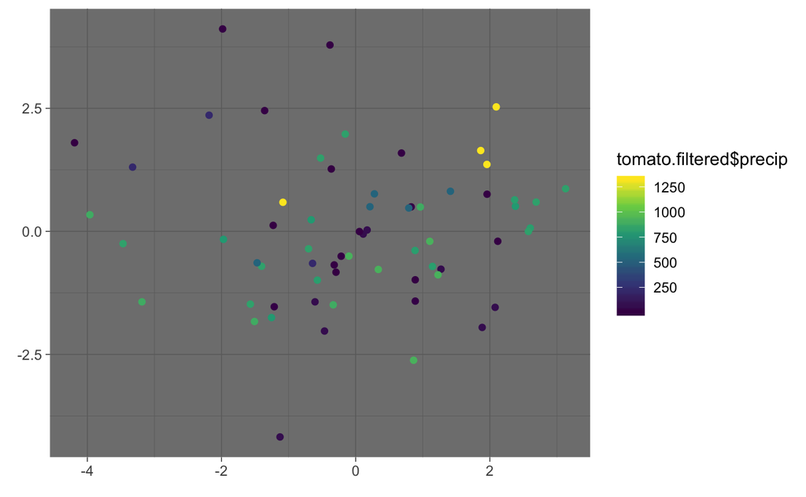

```r
tom.pca.data <- get_plotdata(tom.pca)
ggplot(tom.pca.data$scores, aes(x = p1, y = p2)) +
  geom_point(aes(color = tomato.filtered$precip)) +
  scale_color_viridis_c() +
  labs(x = glue("P1 ({tom.pca.data$var_explained[1,1] * 100}%)"),
       y = glue("P2 ({tom.pca.data$var_explained[2,1] * 100}%)")) +
  theme_dark()
```

## 2.5 PCA-regression on precipitation

```r
tomato.1 <- tomato.filtered %>% add_column(pc1 = tom.pca.data$scores$p1)
m1 <- lm(precip ~ pc1, data = tomato.1)
lmtest::lrtest(m1)
```

```
Likelihood ratio test

Model 1: precip ~ pc1
Model 2: precip ~ 1
  #Df  LogLik Df  Chisq Pr(>Chisq)
1   3 -485.57
2   2 -486.19 -1 1.2478      0.264
```

```r
summary(m1)
```

```
Call:
lm(formula = precip ~ pc1, data = tomato.1)

Residuals:
    Min      1Q  Median      3Q     Max
-577.01 -447.39   64.29  351.94  853.74

Coefficients:
            Estimate Std. Error t value Pr(>|t|)
(Intercept)   508.43      53.51   9.502 8.84e-14 ***
pc1            35.21      31.86   1.105    0.273
---
Signif. codes:  0 ‘***’ 0.001 ‘**’ 0.01 ‘*’ 0.05 ‘.’ 0.1 ‘ ’ 1

Residual standard error: 431.4 on 63 degrees of freedom
Multiple R-squared:  0.01901,   Adjusted R-squared:  0.003443
F-statistic: 1.221 on 1 and 63 DF,  p-value: 0.2733
```

PC1 doesn’t explain variation in precipitation without *S. juglandifolium* included.

## 2.6 PLSR on precipitation

PLS regression produces only a single component model, but thecross-validation and permutation testing is good!

```r
tom.plsr <-
  opls(tomato.filtered %>% dplyr::select(lma.leaflet:Rdark), tomato.filtered$precip,
       plotL = FALSE, permI = 200)
```

```
PLS
65 samples x 9 variables and 1 response
standard scaling of predictors and response(s)
4 (1%) NAs
```

|  | R2X(cum) | R2Y(cum) | Q2(cum) | RMSEE | pre | ort | pR2Y | pQ2 |
| --- | --- | --- | --- | --- | --- | --- | --- | --- |
| Total | 0.199 | 0.421 | 0.336 | 331 | 1 | 0 | 0.005 | 0.005 |

```r
# single component model
```

**OPLS plot:**

For the sake of visualization, I’ll plot an OPLS score plot

```r
#plot OPLS for the sake of visualization
tom.oplsr <-
  opls(tomato.filtered %>% dplyr::select(lma.leaflet:Rdark), tomato.filtered$precip,
       plotL = FALSE, permI = 200, predI = 1, orthoI = NA)
```

```
OPLS
65 samples x 9 variables and 1 response
standard scaling of predictors and response(s)
4 (1%) NAs
```

|  | R2X(cum) | R2Y(cum) | Q2(cum) | RMSEE | pre | ort | pR2Y | pQ2 |
| --- | --- | --- | --- | --- | --- | --- | --- | --- |
| Total | 0.443 | 0.452 | 0.414 | 325 | 1 | 1 | 0.005 | 0.005 |

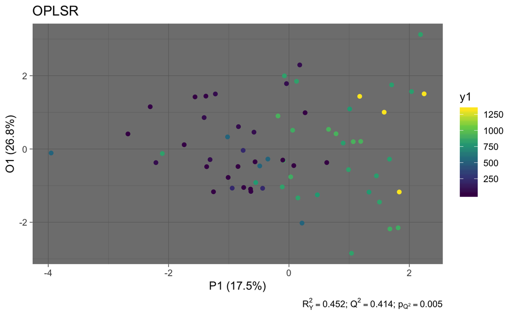

```r
plot_opls(tom.oplsr) + theme_dark()
```

**PLSR Loadings:**

```r
get_loadings(tom.plsr) %>%
  arrange(desc(abs(p1)))
```

| Variable | p1 |
| --- | --- |
| lma.leaflet | 0.738434871 |
| ldmc | 0.567381475 |
| thick.vile | 0.394143377 |
| Rdark | 0.264750769 |
| Vcmax | 0.080981693 |
| gm | -0.034003894 |
| wue | -0.030163460 |
| A | 0.011730713 |
| gs | -0.007159333 |

Leaf mass per area (LMA) and leaf dry matter content (LDMC) seem to be positively related to precipitation. This indicates that thinner leaves are associated with drier habitats. That seems counter-intuitive, but the authors also thought their results were counter-intuitive.